# Reporte estadístico de los resultados de una encuesta

**Autor:** Alex Bajaña **Tema:** La Responsabilidad Social Empresarial en la Seguridad y Salud en el Trabajo **Fecha de elaboración:** Noviembre 11, 2023

Un producto del Centro de Investigación Estadística ERGOSTATS

```python
%run -n analisis.py
```

[output not shown]

[output cut: 52 more lines]

```python
df.columns
```

```
Index(['Marca temporal', 'Nombre de la empresa',
       '1.-¿La empresa tiene algún modelo que involucre la responsabilidad social y seguridad laboral en la construcción de puentes?',
       '2.-¿La empresa aplica la responsabilidad social y ambiental con seguridad laboral en el proceso de la construcción de puentes y vías?',
       '3.-¿La empresa conoce los estándares y normas éticas en la construcción de puentes y vías?',
       '4.-¿La empresa se mantiene actualizada en seguridad y responsabilidad social en cuanto a las tendencias y las regulaciones de la industria en construcción de puentes ?',
       '5.-¿Se realiza una evaluación periódica de los avances en materia de seguridad laboral y responsabilidad social en la construcción en su empresa?',
       '6.-¿La empresa cuenta con especialistas para alinear y actualizar las operaciones en cuanto a seguridad con responsabilidad social?',
       '7.-¿Planifican la responsabilidad social en la construcción de puentes?',
       '8.- ¿Existe un cronograma para revisar y actualizar el plan o sistema de seguridad laboral con responsabilidad social?',
       '9.- ¿La empresa ha realizado prácticas de mejoramiento en seguridad y salud laboral?',
       '10.-¿Las comunidades aledañas a la construcción de puentes y vías han presentado quejas respecto a las operaciones de la empresa?',
       '11.-¿Se han planteado estrategias para minimizar el daño social y/o ambiental?',
       '12.-¿La empresa cuida la integridad física, mental y emocional de sus colaboradores?',
       '13.-¿Piensa usted que se aplica en la construcción de puentes y vías el Reglamento de Seguridad y Salud de los Trabajadores con responsabilidad social?',
       '14.-¿A tenido pérdidas económicas por no aplicar un modelo o plan de seguridad o responsabilidad social en la construcción?',
       'Puntuación'],
      dtype='object')
```

## Conocimiento de normas y estandares contra aplicación de prácticas responsables

- Preguntas 2 y 3

```python
print(df.columns[3],"\n",df.columns[4])
```

```
2.-¿La empresa aplica la responsabilidad social y ambiental con seguridad laboral en el proceso de la construcción de puentes y vías?
 3.-¿La empresa conoce los estándares y normas éticas en la construcción de puentes y vías?
```

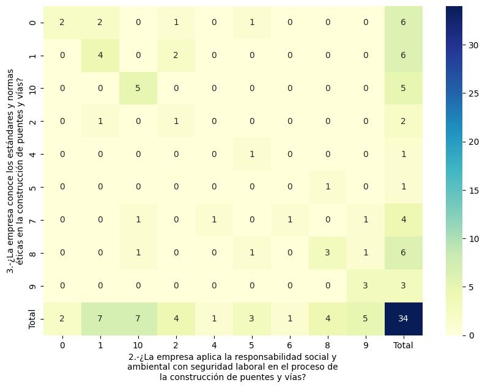

```python
contingency_table = contingency_table_analysis(df, df.columns[3], df.columns[4])

heat_plot(df, df.columns[3], df.columns[4])
```

```python
p = print_contingency_table(contingency_table)
```

```
Chi-cuadrado: 110.18968253968254
p-valor: 0.01719981784496004
Grados de libertad: 81
```

La relación entre estas variables es estadísticamente siginificativa.

## Conocimiento de normas y estandares contra planificación de la responsabilidad social en la construcción de puentes

- Preguntas 3 y 7

```python
print(df.columns[4],"\n",df.columns[8])
```

```
3.-¿La empresa conoce los estándares y normas éticas en la construcción de puentes y vías?
 7.-¿Planifican la responsabilidad social en la construcción de puentes?
```

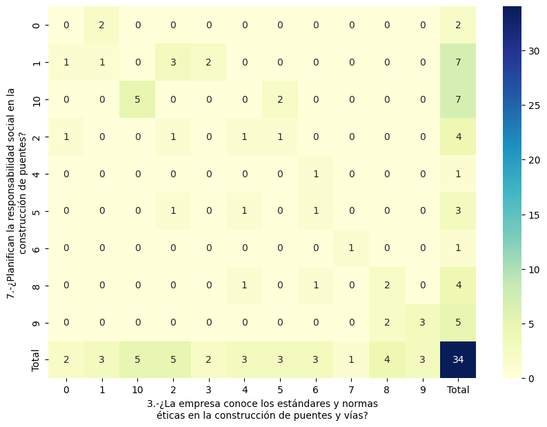

```python
contingency_table = contingency_table_analysis(df, df.columns[4], df.columns[8])

heat_plot(df, df.columns[4], df.columns[8])
```

```python
p = print_contingency_table(contingency_table)
```

```
Chi-cuadrado: 150.07222222222225
p-valor: 0.0007107769085085141
Grados de libertad: 99
```

La relación entre estas variables es estadísticamente siginificativa.

## Conocimiento actualizado sobre tendencias y regulaciones de seguridad y responsabilidad social y la aplicación de prácticas

- Preguntas 4 y 2

```python
print(df.columns[5],"\n",df.columns[3])
```

```
4.-¿La empresa se mantiene actualizada en seguridad y responsabilidad social en cuanto a las tendencias y las regulaciones de la industria en construcción de puentes ?
 2.-¿La empresa aplica la responsabilidad social y ambiental con seguridad laboral en el proceso de la construcción de puentes y vías?
```

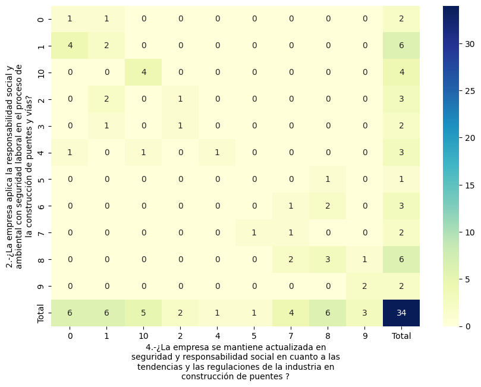

```python
contingency_table = contingency_table_analysis(df, df.columns[5], df.columns[3])

heat_plot(df, df.columns[5], df.columns[3])
```

```python
p = print_contingency_table(contingency_table)
```

```
Chi-cuadrado: 133.82777777777775
p-valor: 0.011332297139666103
Grados de libertad: 99
```

La relación entre estas variables es estadísticamente siginificativa.

## Evaluación de avance y conocimientos actualizados

- Preguntas 5 y 4

```python
print(df.columns[6],"\n",df.columns[5])
```

```
5.-¿Se realiza una evaluación periódica de los avances en materia de seguridad laboral y responsabilidad social en la construcción en su empresa?
 4.-¿La empresa se mantiene actualizada en seguridad y responsabilidad social en cuanto a las tendencias y las regulaciones de la industria en construcción de puentes ?
```

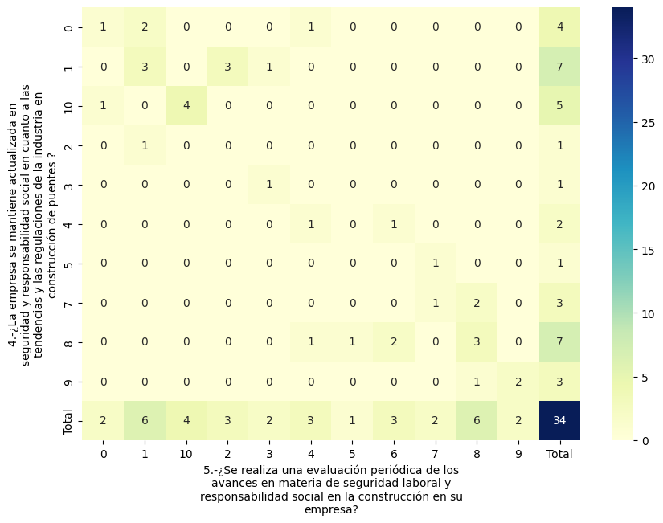

```python
contingency_table = contingency_table_analysis(df, df.columns[6], df.columns[5])

heat_plot(df, df.columns[6], df.columns[5])
```

```python
p = print_contingency_table(contingency_table)
```

```
Chi-cuadrado: 142.6515873015873
p-valor: 0.01975406065309294
Grados de libertad: 110
```

La relación entre estas variables es estadísticamente siginificativa.

## Evaluaciones periodicas y cuidado de la empresa hacía sus trabajadores

- Preguntas 5 y 12

```python
print(df.columns[6],"\n",df.columns[13])
```

```
5.-¿Se realiza una evaluación periódica de los avances en materia de seguridad laboral y responsabilidad social en la construcción en su empresa?
 12.-¿La empresa cuida la integridad física, mental y emocional de sus colaboradores?
```

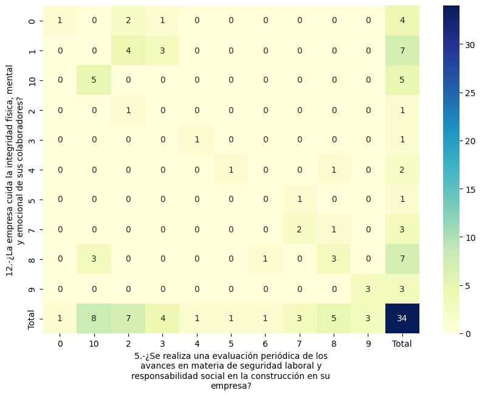

```python
contingency_table = contingency_table_analysis(df, df.columns[6], df.columns[13])

heat_plot(df, df.columns[6], df.columns[13])
```

```python
p = print_contingency_table(contingency_table)
```

```
Chi-cuadrado: 165.7952947845805
p-valor: 3.933034213330658e-05
Grados de libertad: 100
```

La relación entre estas variables es estadísticamente siginificativa.

## Planificación de responsabilidad social y cuidado de la empresa hacía sus trabajadores

```python
print(df.columns[8],"\n",df.columns[13])
```

```
7.-¿Planifican la responsabilidad social en la construcción de puentes?
 12.-¿La empresa cuida la integridad física, mental y emocional de sus colaboradores?
```

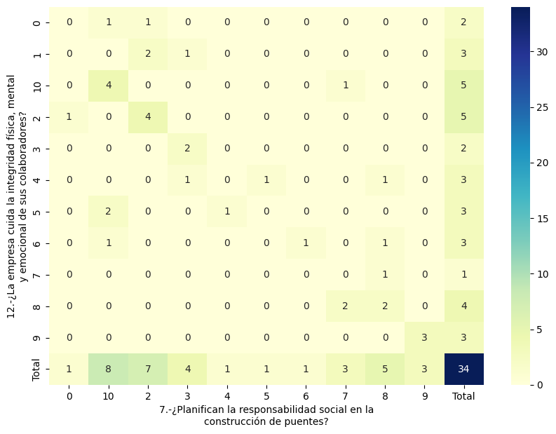

```python
contingency_table = contingency_table_analysis(df, df.columns[8], df.columns[13])

heat_plot(df, df.columns[8], df.columns[13])
```

```python
p = print_contingency_table(contingency_table)
```

```
Chi-cuadrado: 142.4559523809524
p-valor: 0.020292552687127558
Grados de libertad: 110
```

La relación entre estas variables es estadísticamente siginificativa.

## Presencia de cronograma para revisión el plan de seguridad social y percepción de aplicación del reglamento

- Preguntas 8 y 13

```python
print(df.columns[9],"\n",df.columns[14])
```

```
8.- ¿Existe un cronograma para revisar y actualizar el plan o sistema de seguridad laboral con responsabilidad social?
 13.-¿Piensa usted que se aplica en la construcción de puentes y vías el Reglamento de Seguridad y Salud de los Trabajadores con responsabilidad social?
```

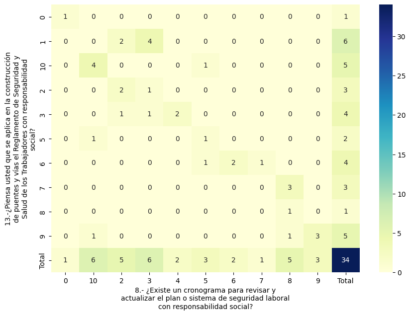

```python
contingency_table = contingency_table_analysis(df, df.columns[9], df.columns[14])

heat_plot(df, df.columns[9], df.columns[14])
```

```python
p = print_contingency_table(contingency_table)
```

```
Chi-cuadrado: 158.04333333333332
p-valor: 0.0001936718962194569
Grados de libertad: 100
```

La relación entre estas variables es estadísticamente siginificativa.

## Mejora de prácticas y percepción de la aplicación de normas

- Preguntas 9 y 13

```python
print(df.columns[10],"\n",df.columns[14])
```

```
9.- ¿La empresa ha realizado prácticas de mejoramiento en seguridad y salud laboral?
 13.-¿Piensa usted que se aplica en la construcción de puentes y vías el Reglamento de Seguridad y Salud de los Trabajadores con responsabilidad social?
```

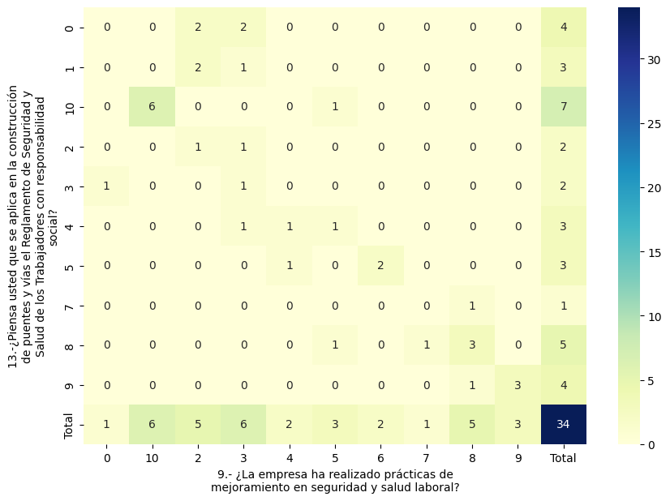

```python
contingency_table = contingency_table_analysis(df, df.columns[10], df.columns[14])

heat_plot(df, df.columns[10], df.columns[14])
```

```python
p = print_contingency_table(contingency_table)
```

```
Chi-cuadrado: 141.224126984127
p-valor: 0.004202159089409846
Grados de libertad: 100
```

La relación entre estas variables es estadísticamente siginificativa.

## Perceptción de la aplicación de normas y aplicación de normas

- Preguntas 13 y 2

```python
print(df.columns[14],"\n",df.columns[3])
```

```
13.-¿Piensa usted que se aplica en la construcción de puentes y vías el Reglamento de Seguridad y Salud de los Trabajadores con responsabilidad social?
 2.-¿La empresa aplica la responsabilidad social y ambiental con seguridad laboral en el proceso de la construcción de puentes y vías?
```

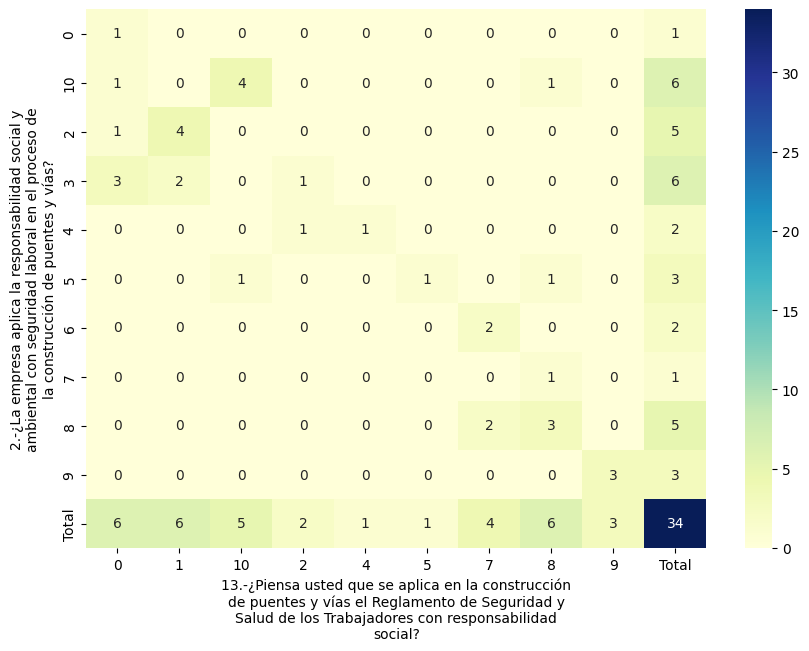

```python
contingency_table = contingency_table_analysis(df, df.columns[14], df.columns[3])

heat_plot(df, df.columns[14], df.columns[3])
```

```python
p = print_contingency_table(contingency_table)
```

```
Chi-cuadrado: 140.72222222222223
p-valor: 0.0005059662222563516
Grados de libertad: 90
```

La relación entre estas variables es estadísticamente siginificativa.